# Unsupervised Methods

Hector Corrada Bravo  
CMSC798: Intro. Data Sci

### Introduction

- So far we have seen “Supervised Methods” where interest is in analyzing a *response* based on various *predictors*.
- In many cases, especially for Exploratory Data Analysis, we want methods to extract patterns on variables without analyzing a specific *response*.
- Methods for the latter case are called “Unsupervised Methods”. Examples are *Principal Component Analysis* and *Clustering*

### Warning

- Interpretation of these methods is much more *subjective* than in Supervised Learning
- For example:
  - we want to know if a given *predictor* is related to *response*: we can do inference using hypothesis testing
  - we want to know which predictors are useful for prediction: use cross-validation to do model selection
  - we want to see how well we predict? Use cross-validation to report on test error
- In unsupervised methods, this is not clean at all
- Nonetheless, they can be very useful methods to understand data at hand

### Motivating Example

*Genotypes across human populations*

- Recent technological advances have allowed identification of locations in human genome (DNA) that vary a lot across human populations (Single Nucleotide Polymorphisms, or SNPs).
- Also allows identifying changes in DNA that are associated with specific traits:
  - e.g., susceptibility to disease, or protection from disease

### Motivating Example

We will look at a dataset of 4,929 SNPs for 1,093 individuals from populations across the globe.

```r
load("geno_data.rda")
print(dim(filtered_geno_data))
```

```
[1] 1093 4929
```

```r
table(filtered_geno_data$super_population)
```

```
AFR AMR EAS EUR OPT
246 181 286 379   1
```

*AFR: Africa, AMR: America, EAS: East Asia, EUR: Europe, OPT: A mystery*

### Motivating Example

| sample_name | population | super_population | rs307377 | rs7366653 | rs41307846 |
| --- | --- | --- | --- | --- | --- |
| perfect | OPT | OPT | 0 | 0 | 0 |
| HG00096 | GBR | EUR | 2 | 0 | 1 |
| HG00097 | GBR | EUR | 2 | 0 | 0 |
| HG00099 | GBR | EUR | 2 | 0 | 0 |
| HG00100 | GBR | EUR | 2 | 0 | 0 |
| HG00101 | GBR | EUR | 2 | 0 | 0 |
| HG00102 | GBR | EUR | 2 | 0 | 0 |
| HG00103 | GBR | EUR | 2 | 0 | 0 |
| HG00104 | GBR | EUR | 2 | 0 | 1 |
| HG00106 | GBR | EUR | 2 | 0 | 0 |
| HG00108 | GBR | EUR | 2 | 0 | 0 |
| HG00109 | GBR | EUR | 2 | 0 | 0 |
| HG00110 | GBR | EUR | 2 | 0 | 0 |
| HG00111 | GBR | EUR | 2 | 0 | 0 |
| HG00112 | GBR | EUR | 2 | 0 | 0 |
| HG00113 | GBR | EUR | 2 | 0 | 0 |
| HG00114 | GBR | EUR | 2 | 1 | 0 |
| HG00116 | GBR | EUR | 2 | 0 | 0 |
| HG00117 | GBR | EUR | 2 | 0 | 0 |
| HG00118 | GBR | EUR | 2 | 0 | 0 |
| HG00119 | GBR | EUR | 2 | 0 | 0 |
| HG00120 | GBR | EUR | 2 | 0 | 0 |
| HG00121 | GBR | EUR | 2 | 0 | 0 |
| HG00122 | GBR | EUR | 2 | 0 | 0 |
| HG00123 | GBR | EUR | 1 | 0 | 0 |
| HG00124 | GBR | EUR | 2 | 0 | 0 |
| HG00125 | GBR | EUR | 2 | 0 | 0 |
| HG00126 | GBR | EUR | 2 | 0 | 0 |
| HG00127 | GBR | EUR | 2 | 0 | 0 |
| HG00128 | GBR | EUR | 2 | 0 | 0 |

[output cut: 1063 more lines]

### Motivating Example

Each of the `rsXXXX` columns corresponds to a SNP (location in the human genome that varies across populations). These are fairly well annotated, e.g, http://snpedia.com/index.php/rs1799971

- The vast majority (about 80%) of people in the world inherited an `A` from both mother and father in this location of their genome. We say they have the `A/A` allele.
- Other people have a different allele, `A/G` or `G/G`, meaning they inherited a mutation (`G` instead of `A`) from either mother or father (in the first case) or both (in the second case).
- These two rare alleles have been associated with increased susceptibility to alcoholism.

### Motivating Example

```r
table(filtered_geno_data$rs1799971)
```

```
  0   1   2
733 305  55
```

In this dataset:

- 733 individuals have the `A/A` allele (coded as `0`)
- 305 have the `A/G` allele (coded as `1`)
- 55 have the `G/G` allele (coded as `2`)

### Motivating Example

All SNPs are coded the same way:

- `0`: they have the most frequent allele
- `1`: they inherited one copy of the mutation
- `2`: they inherited two copies of the mutation

We want to visualize this data for 4k variables!

### Principal Component Analysis

A dimensionality reduction method: *embed data in high dimensional space to small number of dimensions we can visualize*

Given:

- Data set \( \{\mathbf{x}_1, \mathbf{x}_2, \ldots, \mathbf{x}_n\} \), where \( \mathbf{x}_i \) is the vector of \( p \) predictor values for the \( i \)-th observation.

Return:

- Matrix \( \left[ \phi_1, \phi_2, \ldots, \phi_p \right] \) of linear transformations that retain maximal variance.

### Principal Component Analysis

The first transformation \( \phi_1 \) defines an embedding of the data into 1 dimension:

\[ Z_1 = \phi_{11}X_1 + \phi_{21} X_2 + \cdots + \phi_{p1} X_p \]

where \( \phi_1 \) is selected so that the resulting dataset \( \{ z_1, \ldots, z_n\} \) has *maximum variance*.

Note: in order for this to make sense:

- data has to be centered, i.e., each \( X_j \) has mean equal to zero
- \( \phi_1 \) has to be normalized, i.e., \( \sum_{j=1}^p \phi_{j1}^2=1 \).

### Principal Component Analysis

We can find \( \phi_1 \) by (surprise!) solving an optimization problem:

\[ \max_{\phi{11},\phi_{21},\ldots,\phi_{p1}} \left\{ \frac{1}{n} \sum_{i=1}^n \left( \sum_{j=1}^p \phi_{j1} x_{ij} \right)^2 \right\} \\ \mathrm{s.t.} \sum_{j=1}^p \phi_{j1}^2 = 1 \]

*maximize variance*  
*subject to normalization constraint*

### Principal Component Analysis

The second transformation \( \phi_2 \) is obtained next solving a similar problem with the added constraint that \( \phi_2 \) **is orthogonal** to \( \phi_1 \).

Taken together \( \left[ \phi_1, \phi_2 \right] \) define a linear transformation of the data into 2 dimensional space.

\[ Z_{n\times 2} = X_{n \times p} \left[ \phi_1, \phi_2 \right]_{p \times 2} \]

### Example

| PC1 | PC2 | PC3 | sample_name | population | super_population |
| --- | --- | --- | --- | --- | --- |
| -2.2208565 | 13.8176265 | -193.8613921 | perfect | OPT | OPT |
| -6.0347539 | 15.9403862 | -0.5350849 | HG00096 | GBR | EUR |
| -6.3073032 | 14.7981564 | -1.0284508 | HG00097 | GBR | EUR |
| -7.0990373 | 15.8130059 | -4.3762353 | HG00099 | GBR | EUR |
| -6.0040517 | 17.2891462 | -0.3868090 | HG00100 | GBR | EUR |
| -7.5450341 | 15.6152855 | 1.1672255 | HG00101 | GBR | EUR |
| -6.4197360 | 15.6946764 | -1.5019768 | HG00102 | GBR | EUR |
| -7.5458569 | 17.8092027 | 0.6258870 | HG00103 | GBR | EUR |
| -8.7018790 | 15.3298474 | 1.1435243 | HG00104 | GBR | EUR |
| -7.1949619 | 15.1391491 | -0.4699450 | HG00106 | GBR | EUR |
| -7.9107437 | 15.0045462 | 0.4331865 | HG00108 | GBR | EUR |
| -6.1616722 | 16.6915006 | -0.8094868 | HG00109 | GBR | EUR |
| -6.1296549 | 15.8388315 | -0.5712044 | HG00110 | GBR | EUR |
| -5.7334983 | 16.2146995 | 0.5338058 | HG00111 | GBR | EUR |
| -5.3251210 | 15.8221252 | 1.1734587 | HG00112 | GBR | EUR |
| -6.8994996 | 16.9807783 | -0.0411114 | HG00113 | GBR | EUR |
| -5.8559391 | 17.1649051 | -1.2622634 | HG00114 | GBR | EUR |
| -6.9187579 | 15.2973928 | -1.6379451 | HG00116 | GBR | EUR |
| -6.3709576 | 15.2237214 | -2.2163053 | HG00117 | GBR | EUR |
| -6.9985318 | 16.1794020 | -2.2201225 | HG00118 | GBR | EUR |
| -6.0821685 | 14.7640170 | 1.7714204 | HG00119 | GBR | EUR |
| -6.5373000 | 18.0062182 | -0.6194924 | HG00120 | GBR | EUR |
| -8.9105164 | 17.3251865 | -1.4989355 | HG00121 | GBR | EUR |
| -5.2544721 | 17.2651001 | -0.1503810 | HG00122 | GBR | EUR |
| -7.5618397 | 16.8264516 | 1.7197816 | HG00123 | GBR | EUR |
| -6.8649617 | 16.0506960 | -0.1413351 | HG00124 | GBR | EUR |
| -7.5180256 | 18.0683275 | 1.0706060 | HG00125 | GBR | EUR |
| -7.4558952 | 15.3720534 | 1.4831357 | HG00126 | GBR | EUR |
| -6.3914232 | 16.3205844 | 0.5178408 | HG00127 | GBR | EUR |
| -6.7127980 | 15.8429078 | -0.4436025 | HG00128 | GBR | EUR |

[output cut: 1063 more lines]

### Some notes

- Each of the columns of the \( Z \) matrix are called *Principal Components*
- The units of the PCs are *meaningless*
- In this case we also scaled the variables \( X_j \) to have unit variance. **I** would not have done that with this dataset, but we'll see why I did it shortly.
- In general, if variables \( X_j \) are measured in different units (e.g, miles vs. liters vs. dollars), variables should be scaled to have unit variance.
- Conversely, if they are all measured in the same units (as in this example), you should not scale them.

### Example

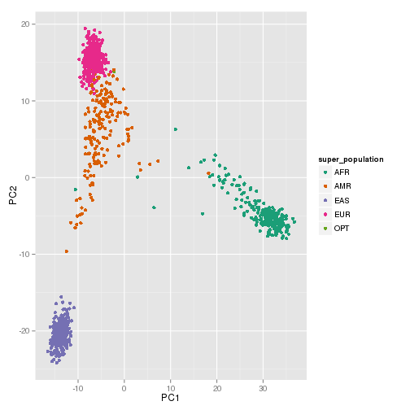

Interpretation:

- First roughly corresponds to African population
- Second component rouhgly corresponds to Eastern Asian population
- America not as well defined as the other populations

### Interpretation

We can also look at \( \phi \)'s (aka *loadings*) to see how much weight each variable is assigned to each PC.

For example, here are the top 10 SNPs for PC1

| SNP | PC1 | PC2 |
| --- | --- | --- |
| rs2740574 | -0.0510 | 0.0072 |
| rs10743430 | -0.0495 | 0.0062 |
| rs2643103 | -0.0484 | 0.0179 |
| rs2032487 | -0.0481 | 0.0050 |
| rs4821480 | -0.0479 | 0.0049 |
| rs4821481 | -0.0479 | 0.0049 |
| rs9891361 | -0.0475 | 0.0102 |
| rs710079 | 0.0467 | -0.0160 |
| rs3136687 | 0.0466 | -0.0114 |
| rs5750248 | -0.0460 | 0.0043 |

### Interpretation

Book has an example of `biplot` which combines visualization of embedded data and loadings. **I don't like it!**

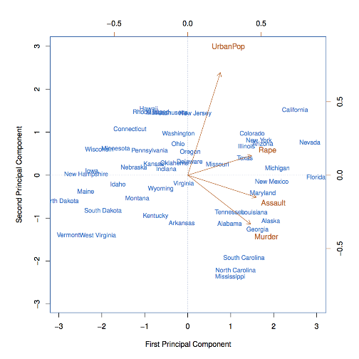

### Practicalities

How many PCs to consider in post-hoc analysis?

A result of PCA is a measure of the variance corresponding to each PC. From that we can calculate the *percentage of variance explained* for the \( m \)-th PC:

\[ PVE_m=\frac{\sum_{i=1}^n z_{im}^2}{\sum_{j=1}^p \sum_{i=1}^n x_{ij}^2} \]

### Practicalities

How many PCs to consider in post-hoc analysis?

We can use this measure to choose number of PCs in an ad-hoc manner

In this case, going further than PC3 does not add information

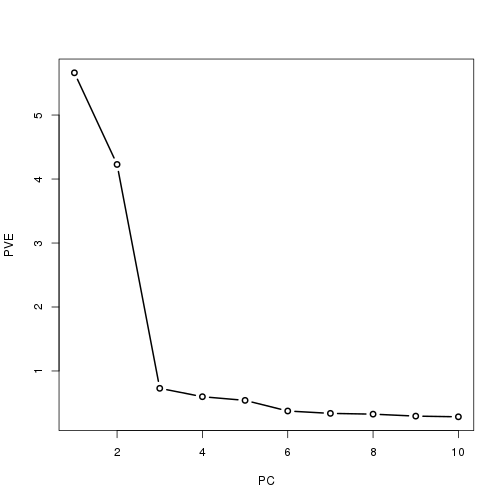

### Practicalities

*Rule of thumb*:

- If no apparent patterns in first couple of PCs, stop!
- Otherwise, look at other PCs using PVE as guide.

Still, this is very much ad-hoc, and no commonly agreed upon method for choosing number of PCs used in practice.

A final caveat: PCA is **notoriously easy** to over-interpret…

### Motivating Example

Let's reveal the source of our motivating data. This came from a blog post by [Lior Pachter](https://math.berkeley.edu/%7Elpachter/) a mathematician and computational biologist.

- He did use real genotype data from the [1000 genomes project](http://www.1000genomes.org/)
- And created, *in silico* a hypothetical human being where each SNP was set optimally
  - i.e., if it's a protective mutation, then mutation was given, if it's a deleterious mutation, then mutation was not inherited

### Example

This hypothetical human being is the `OPT` population

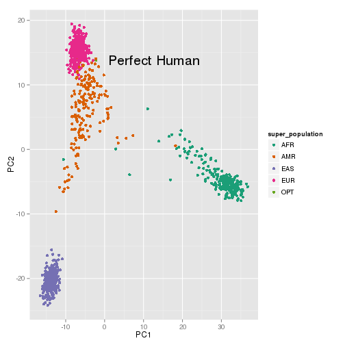

### Example

Which from PC3 you can see it is indeed hypothetical

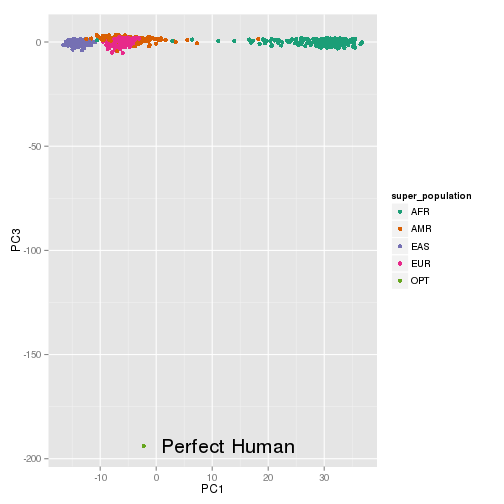

### Example

Now, things got interesting when he reported that the nearest individual in the *embedded* dataset to this perfect human was a Puerto Rican woman:

[1] “[HG00737](https://catalog.coriell.org/0/sections/Search/Sample_Detail.aspx?Ref=HG00737&PgId=166)”

[Medical Daily](http://www.medicaldaily.com/biologist-says-puerto-rican-women-possess-ideal-genotype-perfect-human-dna-ancestry-313956)  
[HuffPost](http://www.huffingtonpost.com/julio-pabon/the-closet-perfect-human-_b_6304366.html)  
[El Nuevo Dia (Puerto Rican Newspaper)](http://clasificados.endi.com/ciencia/ciencia/nota/serhumanoperfectoseriapuertorriqueno-1903858/) [Google Translate](https://translate.google.com/translate?hl=en&sl=auto&tl=en&u=http%3A%2F%2Fclasificados.endi.com%2Fciencia%2Fciencia%2Fnota%2Fserhumanoperfectoseriapuertorriqueno-1903858%2F)  
[Latin Times](http://www.latintimes.com/new-study-reveals-perfect-human-genetically-speaking-caribbean-island-280363)  
[The Backlash…](http://globalvoicesonline.org/2014/12/17/the-perfect-human-doesnt-live-in-puerto-rico-or-any-other-country/)

[*and a lot more*](https://www.google.com/?gws_rd=ssl#q=perfect+human+pachter)

### Summary

Principal Component Analysis

- Conceptually simple
- Powerful EDA tool, very useful.
- Interpretation very ad-hoc
- Part of large set of unsupervised methods based on *matrix decompositions*